# Modelo generativo-predictivo de matrículas a partir del PIB

# Introducción:

vamos a elaborar modelos que calculen el número de matrículas un dado nivel educativo para cada departamento a partir del algunos de los valores del PIB del mismo año. Esto permitirá establecer la cantidad y magnitud de la afectación de las diferentes industrias (subvalores del PIB departamental) sobre el número de matrículas en los diferentes niveles educativos.

## Objetivo general:

## Objetivos específicos:

1. Obtención, transformación, limpieza y ordenado de datos.
2. Análisis exploratorio de datos.
3. Creación de un modelo lineal regresivo por cada nivel educativo.
4. Análisis de los pesos de las variables y sus p-values.
5. Reflexiones.
6. Predicciones de los PIB necesarios para alimentar los modelos lineales en tres (3) departamentos.
7. Análisis de los pesos de los tn para las predicciones.
8. Alimentación de los modelos previamente creados para calcular la demanda de matrículas por nivel académico para 2016 y 2017 en los tres (3) departamentos.
9. Conclusiones.

## Estado de la cuestión:

## 1. Obteniendo datos:

Los datos que vamos a tomar provienen de la página del MEN, del DANE y de [datos abiertos](https://www.datos.gov.co).

En su estado original no tenían la disposición que vamos a darle, por eso reseñamos los links en los que pueden encontrarlos en su estado original.

El principal trabajo consistió en diseñar la disposición del set de datos de manera que sea útil para alimentar un modelo lineal regresivo, series de tiempo, modelos de aprendizaje automático e incluso modelos neuronales.

### 1.1. Datos sobre matrículas:

Las matrículas que en cada año en cada departamento se hacen. Esto por cada nivel educativo:

```r
setwd("~/Documents/datathonlatam") ## setting dir
library(readr)
arc <- list.files("./datasets/educacion_superior", pattern = ".csv") ## creating list files csv

matricula <- read_csv(paste("./datasets/educacion_superior", arc[4], sep = "/"))
names(matricula) <- c("departamento", "anio",
                      paste("matr", gsub("tecnica profesional", "tecpro", tolower(names(matricula)[3:8])), sep = "_") )
```

Tenemos un set de datos de 198 filas por 8 columnas que contiene los 33 departamentos: AMAZONAS, ANTIOQUIA, ARAUCA, ATLANTICO, BOGOTA D.C., BOLIVAR, BOYACA, CALDAS, CAQUETA, CASANARE, CAUCA, CESAR, CHOCO, CORDOBA, CUNDINAMARCA, GUAINIA, GUAVIARE, HUILA, LA GUAJIRA, MAGDALENA, META, NARINO, NORTE DE SANTANDER, PUTUMAYO, QUINDIO, RISARALDA, SAN ANDRES Y PROVIDENCIA, SANTANDER, SUCRE, TOLIMA, VALLE DEL CAUCA, VAUPES, VICHADA. Esto para los años 2010, 2011, 2012, 2013, 2014, 2015 y para los niveles educativos matr_tecpro, matr_tecnologica, matr_universitaria, matr_especializacion, matr_maestria, matr_doctorado. Una muestra:

```r
head(matricula)
```

```
## # A tibble: 6 × 8
##   departamento  anio matr_tecpro matr_tecnologica matr_universitaria
##          <chr> <int>       <int>            <int>              <int>
## 1    ATLANTICO  2010        5297            12083              63339
## 2      BOLIVAR  2010        2603            18802              31854
## 3        CESAR  2010         376             4924              16067
## 4      CORDOBA  2010        1362             4210              21658
## 5   LA GUAJIRA  2010        1059             4579               8474
## 6    MAGDALENA  2010        1636             5599              15815
## # ... with 3 more variables: matr_especializacion <int>,
## #   matr_maestria <int>, matr_doctorado <int>
```

### 1.2. Datos sobre PIB:

El Producto Interno Bruto por departamento, por año, desagregado en sus 47 componentes:

```r
totalpib <- data.frame() ## empty data frame to fill
k <- 0 ## a counter for naming by department from departamentos var
departamentos <- readRDS("./departamentosRDS")
library(readxl) ## library needed to read xls
for(i in seq(from = 2, to = 66, by = 2)) { ## We'll read even sheets (by number, not by name)

pib <- read_excel("~/Documents/datathonlatam/datasets/Copia de PIB_Departamentos_2015provisional.xls",
                 sheet = i, skip = 5, range = "A7:Q59") ## read just a range of the sheet
pib <- pib[!is.na(pib[, 1]) & !is.na(pib[, 2]), c(1, 2:16)] ## delete NAs and keep 2010 to 2015
pib <- data.frame(t(pib)) ## transpose
k <- k + 1 ## increase 'iterator' of departamentos names
pib$departamento <- departamentos[k] ## namig the departamento
pib$anio <- rownames(pib) ## anio as value not just as rowname
pib <- pib[c(2:nrow(pib)), c(48:49, 1:47)] ## erasing first row and reordering cols-vars
totalpib <- rbind(totalpib, pib) ## stacking results in one data frame
}

rm(pib) ## erase inecessary data frame

totalpib[, 3:ncol(totalpib)] <- apply(totalpib[, 3:ncol(totalpib)], 2, as.integer) ## data as numeric

library(readr)
dummy_names_PIB <- as.data.frame(read_csv("~/Documents/datathonlatam/dummy_names_PIB.csv")[, c(1:2)])
```

Los nombres de cada uno de las subvariables del PIB por departamento anual tuvieron que ser sustituidas en su orden por variables X1, X2, X3, … , X47. Sus nombres reales se listan:

```r
dummy_names_PIB[, 2]
```

```
##  [1] "AGRICULTURA, GANADERIA, CAZA, SILVICULTURA Y PESCA"
##  [2] "Cultivo de café"
##  [3] "Cultivo de otros productos agrícolas"
##  [4] "Producción pecuaria y caza incluyendo las actividades veterinarias"
##  [5] "Silvicultura, extracción de madera y actividades conexas"
##  [6] "Pesca, produccion de peces en criaderos y granjas piscícolas; actividades de servicios relacionadas con la pesca"
##  [7] "EXPLOTACION DE MINAS Y CANTERAS"
##  [8] "Extracción de carbón, carbón lignítico y turba"
##  [9] "Extracción de petróleo crudo y de gas natural; actividades de servicios relacionadas con la extracción de petróleo y de gas, excepto las actividades de prospección; extracción de minerales de uranio y de torio"
## [10] "Extracción de minerales metáliferos"
## [11] "Extracción de minerales no metálicos"
## [12] "INDUSTRIA MANUFACTURERA"
## [13] "Alimentos, bebidas y tabaco"
## [14] "Resto de la Industria"
## [15] "SUMINISTRO DE ELECTRICIDAD, GAS Y AGUA"
```

[output cut: 32 more lines]

Tenemos un set de datos de 495 filas por 49 columnas que contiene los 33 departamentos: AMAZONAS, ANTIOQUIA, ARAUCA, ATLANTICO, BOGOTA D.C., BOLIVAR, BOYACA, CALDAS, CAQUETA, CASANARE, CAUCA, CESAR, CHOCO, CORDOBA, CUNDINAMARCA, GUAINIA, GUAVIARE, HUILA, LA GUAJIRA, MAGDALENA, META, NARINO, NORTE DE SANTANDER, PUTUMAYO, QUINDIO, RISARALDA, SAN ANDRES Y PROVIDENCIA, SANTANDER, SUCRE, TOLIMA, VALLE DEL CAUCA, VAUPES, VICHADA. Esto para los años 2000, 2001, 2002, 2003, 2004, 2005, 2006, 2007, 2008, 2009, 2010, 2011, 2012, 2013, 2014 y para las 47 variables reseñadas antes.

### 1.3. Datos sobre proyecciones poblacionales:

El DANE, a partir del CENSO 2005 hizo proyecciones sobre la población en cada uno de los departamentos. Estos datos son los que tomamos.

```r
library(readr)
dane <- read_csv("./datasets/censo 2005/proyeccion poblacion DANE 2005.csv")

totaldane <- data.frame()
for( i in 1:nrow(dane)){
    temp <- data.frame(departamento = dane[i, 1],
                                  anio = seq(1985, 2020),
                                  proy = as.numeric(dane[i, 2:ncol(dane)]))
    totaldane <- rbind(totaldane, temp)
}

rm(list = c("dane", "temp"))
```

Tenemos un set de datos de 1188 filas por 3 columnas que contiene los 33 departamentos: AMAZONAS, ANTIOQUIA, ARAUCA, ATLANTICO, BOGOTA D.C., BOLIVAR, BOYACA, CALDAS, CAQUETA, CASANARE, CAUCA, CESAR, CHOCO, CORDOBA, CUNDINAMARCA, GUAINIA, GUAVIARE, HUILA, LA GUAJIRA, MAGDALENA, META, NARINO, NORTE DE SANTANDER, PUTUMAYO, QUINDIO, RISARALDA, SAN ANDRES Y PROVIDENCIA, SANTANDER, SUCRE, TOLIMA, VALLE DEL CAUCA, VAUPES, VICHADA. Esto para los años 1985, 1986, 1987, 1988, 1989, 1990, 1991, 1992, 1993, 1994, 1995, 1996, 1997, 1998, 1999, 2000, 2001, 2002, 2003, 2004, 2005, 2006, 2007, 2008, 2009, 2010, 2011, 2012, 2013, 2014, 2015, 2016, 2017, 2018, 2019, 2020.

### 1.4. Juntando todos los datos:

```r
df <- merge(merge(totaldane, totalpib), matricula)
df$departamento <- as.factor(df$departamento)
df$proy <- as.integer(df$proy)
str(df)
```

```
## 'data.frame':    165 obs. of  56 variables:
##  $ departamento        : Factor w/ 33 levels "AMAZONAS","ANTIOQUIA",..: 1 1 1 1 1 2 2 2 2 2 ...
##  $ anio                : int  2010 2011 2012 2013 2014 2010 2011 2012 2013 2014 ...
##  $ proy                : int  45509584 46044601 46581823 47121089 47661787 4383277 4428675 4474369 4520480 4566875 ...
##  $ X1                  : int  53 50 51 52 61 4495 4859 4874 5206 5420 ...
##  $ X2                  : int  0 0 0 0 0 645 754 562 690 761 ...
##  $ X3                  : int  0 1 0 0 0 2201 2354 2471 2592 2520 ...
##  $ X4                  : int  2 2 2 2 2 1544 1627 1702 1766 1924 ...
##  $ X5                  : int  7 7 8 10 9 89 103 114 132 183 ...
##  $ X6                  : int  44 40 41 40 50 16 21 25 26 32 ...
##  $ X7                  : int  0 0 0 0 0 1718 2434 2985 2853 2645 ...
##  $ X8                  : int  0 0 0 0 0 17 43 19 11 25 ...
##  $ X9                  : int  0 0 0 0 0 749 1155 1432 1553 1232 ...
##  $ X10                 : int  0 0 0 0 0 697 931 1218 928 927 ...
##  $ X11                 : int  0 0 0 0 0 255 305 316 361 461 ...
```

[output cut: 42 more lines]

## 2. Análisis exploratorio de datos.

Ahora que hemos definido nuestro set de datos vamos a explorarlo. Lo primero que necesitamos es remover algunas variables del PIB que son suma de otras (X1 es la suma de X2 a X6, X7 es la suma de X8 a X11 … Las que aparecen relacionadas en mayúsculas son la suma de las siguientes en minúsculas, de acuerdo con la tabla presentada en el apartado 1.2. Datos sobre PIB:) ya que son redundantes.

```r
df_limpio <- df[, -c(4, 10, 15, 18, 23, 26, 30, 36, 40, 48:50)]
correlaciones <- cor(df_limpio[, c(2:ncol(df_limpio))])
```

Pasamos de tener un set de datos de 165 por 56 a tener uno de 165 por 44

### 2.2. Revisando correlaciones:

Una vez retiradas las variables podemos revisar las correlaciones entre todas las variables del PIB y las de matrículas en educación superior por nivel educativo; dejando por fuera los datos no numéricos ( los nombres de los departamentos):

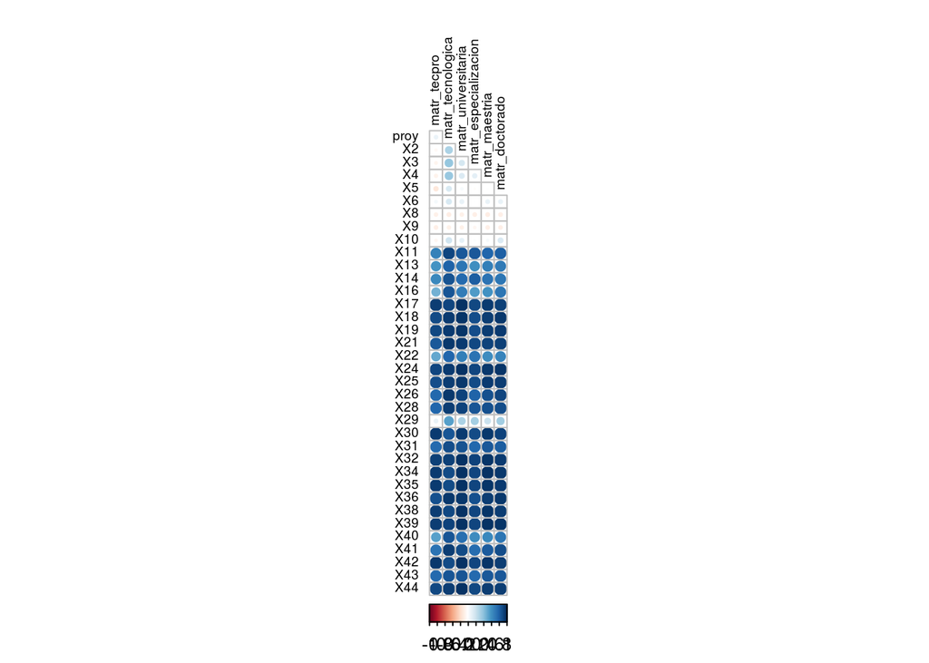

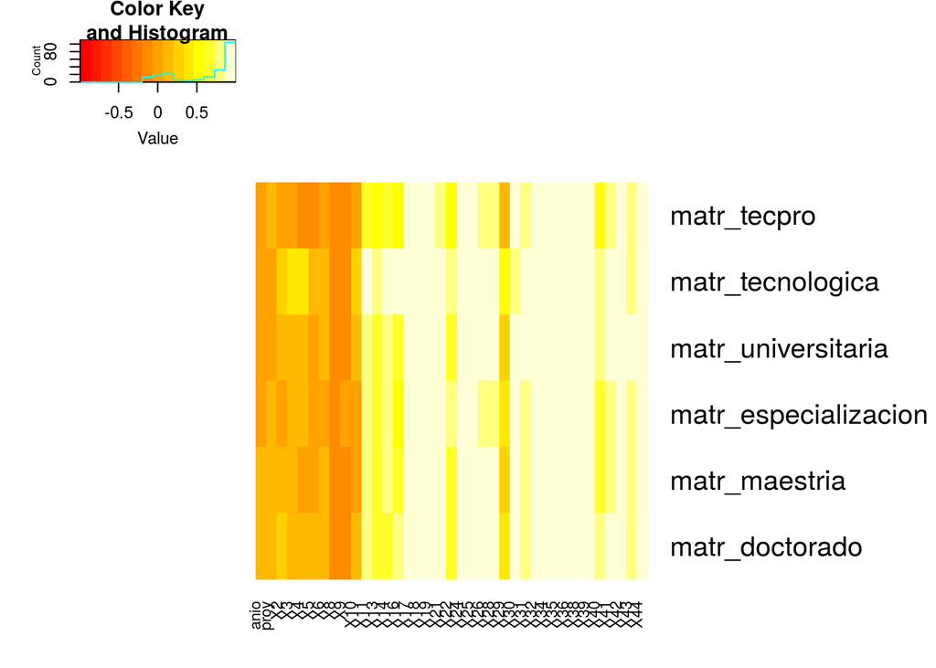

## 3. Creación de un modelo lineal regresivo por cada nivel educativo.

## 4. Análisis de los pesos de las variables y sus p-values.

## 5. Reflexiones.

## 6. Predicciones de los PIB necesarios para alimentar los modelos lineales en tres (3) departamentos.

## 7. Análisis de los pesos de los tn para las predicciones.

## 8. Alimentación de los modelos previamente creados para calcular la demanda de matrículas por nivel académico para 2016 y 2017 en los tres (3) departamentos.

## 9. Conclusiones.